# R Notebook

# Trabajo Practico

Primero cargamos las librerias necesarias:

```r
library(quantreg);
library(readxl); # para leer archivos xml, pero vamos a usar el paquete eph
#library(eph);
library(dplyr);
library(tidyr)
library(ggplot2)
```

### 1.a.

Hacemos las restricciones, y calculamos la variable anios_educacion en funcion de CH14 (ultimo anio de aprobacion), luego lo mismo para experiencia potencial y su cuadrado.

Hacemos una limpieza: como quitar los valores de anios_educacion por encima de 100, ya que son valores que provienen de educacion especial o Ns/Nr

```r
#base2024 <- get_microdata(year = 2024) # para leer usando el paquete eph
base2024 <- read_excel('EPH_usu_1er_Trim_2024_xlsx/usu_individual_T124.xlsx')
base2024 <- base2024[base2024$P21>0 &      ## asalariados
                       base2024$CH03 == 01 & ## jefes de hogar
                       base2024$CH04 == 1 &  ## varones
                       25 <= base2024$CH06 & ## edades
                       base2024$CH06 <= 65,]
#1.a
anios_prev <- c(0, 0, 6, 6, 9, 12, 12, 18)
anios_post <- c(0, 6, 9, 12, 12, 15, 18, 22)

base2 <- base2024 %>%
  mutate(
    # Asignar el número de años en base al nivel de educación y condición de finalización
    anios_educacion = ifelse(CH13 == 1,
                      anios_post[CH12 + 1],  # +1 para ajustar al índice en R
                      anios_prev[CH12 + 1] + as.numeric(CH14)),

    # Calcular la experiencia potencial y su cuadrado
    exp_pot = CH06 - anios_educacion - 6,
    exp_pot_2 = exp_pot^2
  )

base2 <- base2[complete.cases(base2[, c("exp_pot")]), ] # nos quitamos los na's.
base2 <- base2[! (base2$anios_educacion > 100),]
```

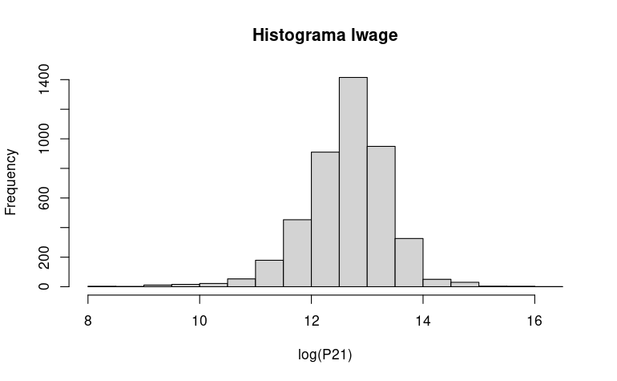

```r
hist(log(base2$P21),main = "Histograma lwage",xlab = "log(P21)")
```

[figure not shown]

### Realizamos el modelo lineal

AGLOMERADO -> ubicacion CH07 -> estado civil CH06 -> edad

```r
reg1 <- lm(log(P21) ~ anios_educacion + exp_pot + exp_pot_2 + as.factor(AGLOMERADO) + as.factor(CH07) + as.factor(CH06), data=base2)
summreq1 <- summary(reg1)
print(summreq1)
```

```
Call:
lm(formula = log(P21) ~ anios_educacion + exp_pot + exp_pot_2 +
    as.factor(AGLOMERADO) + as.factor(CH07) + as.factor(CH06),
    data = base2)

Residuals:
    Min      1Q  Median      3Q     Max
-4.5690 -0.3479  0.0611  0.4023  3.4415

Coefficients: (1 not defined because of singularities)
                         Estimate Std. Error t value Pr(>|t|)
(Intercept)             11.792386   0.167886  70.241  < 2e-16 ***
anios_educacion          0.049376   0.004108  12.019  < 2e-16 ***
exp_pot                  0.018912   0.006549   2.888 0.003899 **
exp_pot_2               -0.000455   0.000111  -4.099 4.22e-05 ***
as.factor(AGLOMERADO)3   0.150075   0.104026   1.443 0.149185
as.factor(AGLOMERADO)4  -0.015503   0.092399  -0.168 0.866758
as.factor(AGLOMERADO)5   0.019554   0.102223   0.191 0.848309
as.factor(AGLOMERADO)6   0.079520   0.098672   0.806 0.420342
as.factor(AGLOMERADO)7  -0.183267   0.097833  -1.873 0.061100 .
as.factor(AGLOMERADO)8  -0.466566   0.099549  -4.687 2.86e-06 ***
as.factor(AGLOMERADO)9   0.546973   0.102313   5.346 9.45e-08 ***
as.factor(AGLOMERADO)10 -0.059872   0.092742  -0.646 0.518587
as.factor(AGLOMERADO)12 -0.277025   0.099314  -2.789 0.005304 **
as.factor(AGLOMERADO)13 -0.086184   0.090671  -0.951 0.341903
as.factor(AGLOMERADO)14 -0.021183   0.099416  -0.213 0.831281
as.factor(AGLOMERADO)15 -0.236288   0.101520  -2.328 0.019984 *
as.factor(AGLOMERADO)17  0.306970   0.104719   2.931 0.003392 **
as.factor(AGLOMERADO)18 -0.412398   0.098515  -4.186 2.89e-05 ***
as.factor(AGLOMERADO)19 -0.160874   0.094929  -1.695 0.090210 .
as.factor(AGLOMERADO)20  0.193278   0.116750   1.655 0.097898 .
as.factor(AGLOMERADO)22 -0.083123   0.099467  -0.836 0.403378
as.factor(AGLOMERADO)23 -0.184265   0.093537  -1.970 0.048905 *
as.factor(AGLOMERADO)25 -0.358696   0.097673  -3.672 0.000243 ***
as.factor(AGLOMERADO)26  0.158788   0.094972   1.672 0.094608 .
as.factor(AGLOMERADO)27 -0.103021   0.096200  -1.071 0.284271
as.factor(AGLOMERADO)29 -0.390447   0.091082  -4.287 1.85e-05 ***
as.factor(AGLOMERADO)30  0.132927   0.108770   1.222 0.221736
as.factor(AGLOMERADO)31  0.527610   0.097597   5.406 6.79e-08 ***
as.factor(AGLOMERADO)32  0.354187   0.093643   3.782 0.000157 ***
```

[output cut: 41 more lines]

```
as.factor(CH06)57       -0.119880   0.105164  -1.140 0.254377
as.factor(CH06)58       -0.079695   0.105597  -0.755 0.450461
as.factor(CH06)59        0.018445   0.111286   0.166 0.868364
as.factor(CH06)60        0.061005   0.111254   0.548 0.583491
as.factor(CH06)61        0.158865   0.113239   1.403 0.160713
as.factor(CH06)62        0.039629   0.112543   0.352 0.724760
as.factor(CH06)63        0.030236   0.110015   0.275 0.783452
as.factor(CH06)64        0.032832   0.117009   0.281 0.779034
as.factor(CH06)65              NA         NA      NA       NA
---
Signif. codes:  0 ‘***’ 0.001 ‘**’ 0.01 ‘*’ 0.05 ‘.’ 0.1 ‘ ’ 1

Residual standard error: 0.6757 on 4349 degrees of freedom
Multiple R-squared:  0.2295,    Adjusted R-squared:  0.2159
F-statistic: 16.82 on 77 and 4349 DF,  p-value: < 2.2e-16
```

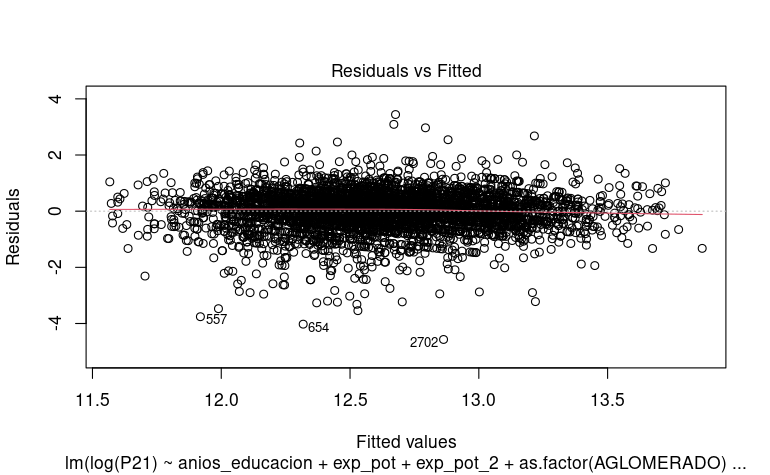

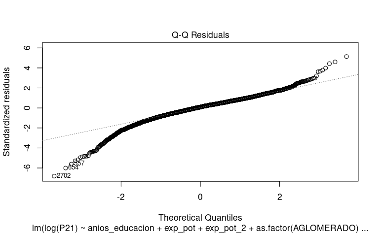

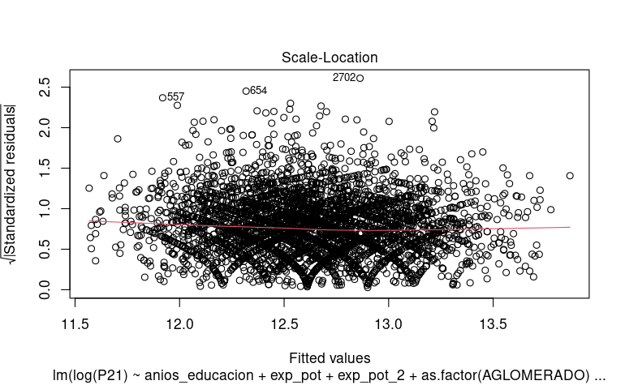

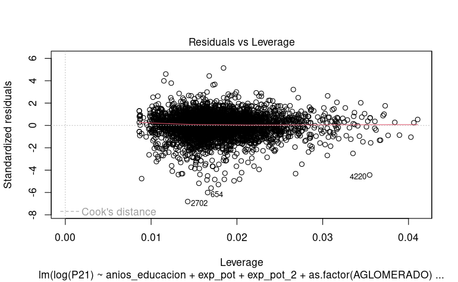

```r
plot(reg1)
```

### Intervalo de confianza de beta1 anios_ed

```r
confint(reg1)[2,]
```

[output not shown]

[figure not shown]

### 1.b.

El primer cambio respecto al modelo previamente evaluado es que al tener la variable CH06 (edad) codificada con dummys, hace que la matriz de disenio no pueda invertise para luego hacer la regresion por cuantiles, por lo tanto opte por quitar esta variable y obtuve estos resultados:

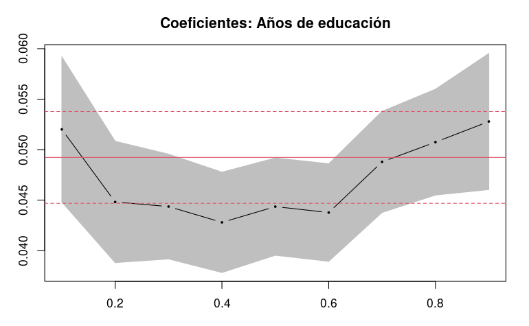

```r
regq1 <- rq(log(P21) ~ anios_educacion + exp_pot + exp_pot_2 + as.factor(AGLOMERADO) + as.factor(CH07),data=base2,tau = 1:9/10,ci = FALSE)
summregq1 <- summary(regq1,se="ker")
plot(summregq1,parm=2,main ="Coeficientes: Años de educación",xlab ="tau's",ylab = "coef ") # con param =2 le decimos que queremos el grafico de valores e intervalos de confianza de años de educacion.
```

Para cuantiles bajos (τ cercanos a 0.1), el coeficiente de años_ed es más alto, lo que indica que el efecto marginal de la educación es mayor entre las personas con ingresos más bajos. En otras palabras, para este grupo, cada año adicional de educación tiene un impacto más fuerte en el aumento de los ingresos. Esto tiene sentido dado que estos individuos, al tener ingresos relativamente bajos, podrían beneficiarse más de la educación en términos de movilidad económica.

A medida que τ se aproxima a 0.5 (mediana de la distribución), el coeficiente de años_ed disminuye, lo que sugiere que, en la mediana de los ingresos, el impacto de la educación es menos pronunciado. Es decir, el efecto marginal de la educación se atenúa en este grupo, lo cual podría indicar que otros factores además de la educación juegan un rol más importante en la determinación de los ingresos.

Finalmente, para los cuantiles altos (τ cercanos a 0.9), el coeficiente de años_ed vuelve a aumentar, lo que sugiere que, para aquellos con ingresos más altos, la educación sigue siendo un factor determinante. Esto podría reflejar que en los niveles más altos de la distribución de ingresos, los años de educación siguen siendo cruciales para alcanzar los ingresos más elevados, probablemente debido a la acumulación de capital humano especializado o credenciales educativas superiores.

Yendo a la pregunta del 1.b Para los individuos en los cuantiles bajos, un año adicional de educación tiene un impacto significativo en el aumento de los ingresos, lo que sugiere que la educación es una vía importante para mejorar su situación económica. Esto puede deberse a que un año más de formación amplía sus oportunidades laborales y su potencial de ingresos de manera considerable. De manera similar, para los individuos en los cuantiles altos de la distribución (τ cercanos a 0.9), la educación sigue siendo un factor determinante para acceder a los ingresos más elevados. En este grupo, la educación, posiblemente en forma de títulos avanzados o especialización, tiene un impacto considerable en aumentar aún más sus ya altos ingresos.

La comparacion grafica que veo es que al usar el modelo de regresion lineal estamos calculando la media de la log de los ingresos y estamos sesgados sobre la interpretacion del coeficiente, y como en este modelo no presenta dicho sesgo, podemos dar mas interpretabilidad del mismo.

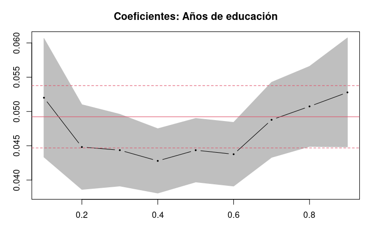

```r
summregq2 <- summary(regq1,se="boot",R=100)
plot(summregq2,parm=2,main ="Coeficientes: Años de educación",xlab ="tau's",ylab = "coef ")
```

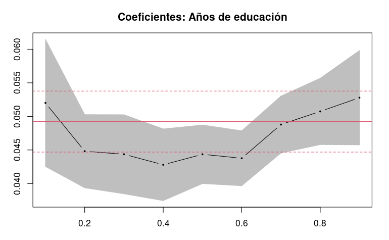

```r
summregq3 <- summary(regq1,se="iid")
plot(summregq3,parm=2,main ="Coeficientes: Años de educación",xlab ="tau's",ylab = "coef ")
```

Habia dicidido no mostrar con los otros metodos (iid boot) por que no vi cambios significativos.